# Lab - Basic R

Author

Daniel Nilsson

Published

November 5, 2025

Modified

October 27, 2025

# Introduction

Many bioinformatics workflows use R as the programming language as it is particularly good at statistical analysis. It is open source and has a large community dedicated for bioinformatics and hosts a variety of statistical tools for efficiently process large amount of biological data (such as DNA, RNA-seq, etc). In this lab we will familiarize us with R and RStudio (the most common code editor for R).

- [R](https://www.r-project.org/)
- [RStudio](https://posit.co/download/rstudio-desktop/)

# Getting Started with RStudio

RStudio is an integrated development environment (IDE) for R, making it easier to write and run R code. Let’s take a quick look at some of its main components:

- **Console**: The Console is where you can run R code interactively. Type code here and press Enter to see immediate results.
- **Script Editor**: Write longer code scripts here (recommended over using the Console for multiple lines of code). To run a line of code, place the cursor on the line and press `Ctrl+Enter` (Windows) or `Cmd+Enter` (Mac).
- **Environment/History**: The Environment tab displays saved variables, while the History tab tracks your command history.
- **Files/Plots/Help**: The Files tab shows your working directory contents. Plots tab displays generated plots, and Help provides documentation.

# R

## Variables

Creating a variable is simply assigning a name to some structure that stores data

```r
8 + 9 #not stored
```

```
[1] 17
```

```r
#storing in a variable name "a"
a <- 8 + 9
a
```

```
[1] 17
```

Obs the `#` which is a comment in the code.

The `<-` is the assignment operator. You can also use `=`.

```r
b = 1 + 9
b
```

```
[1] 10
```

However, `<-` is more widely used for assigning while `=` is usually only for setting arguments in a function (more on this later).

## Types, Classes, Modes

- Types: Basic data types include integers, characters, logicals, and numerics.
- Classes: Define the structure of data, such as numeric, character, factor, etc.
- Modes: Describe the nature of elements in an object (e.g., numeric, character).

```r
x <- 1
class(x) #what type of object is it for R
```

```
[1] "numeric"
```

```r
typeof(x) #what R thinks it is
```

```
[1] "double"
```

```r
mode(x) #how S language would see it
```

```
[1] "numeric"
```

```r
storage.mode(x) #how is it stored in the memory
```

```
[1] "double"
```

We can also cast one type to another

```r
x <- 2
class(x)
```

```
[1] "numeric"
```

```r
typeof(x)
```

```
[1] "double"
```

```r
x <- as.character(x)
class(x)
```

```
[1] "character"
```

```r
typeof(x)
```

```
[1] "character"
```

For characters, they are represented inside “”

```r
my_char <- "Hello"

my_char
```

```
[1] "Hello"
```

```r
class(my_char)
```

```
[1] "character"
```

```r
typeof(my_char)
```

```
[1] "character"
```

OBS we cannot convert characters to a numeric value

```r
my_char <- as.numeric(my_char)
my_char
```

```
[1] NA
```

Another class is logical. The logical class in R is used to represent Boolean values: TRUE and FALSE. Logical values are essential for making decisions in code, as they help in performing conditional checks and filtering data. Here’s a quick overview:

- Creating Logical Values: Logical values can be created directly by assigning TRUE or FALSE to a variable, or as a result of a comparison (e.g., x <- 5 > 3 will set x to TRUE).
- Logical Operations: Logical operators allow for comparisons:
  - `==` for equality, `!=` for inequality
  - `<`, `>`, `<=`, `>=` for comparisons
  - `&` for “and” conditions, `|` for “or” conditions

```r
5 == 5 #TRUE
```

```
[1] TRUE
```

```r
6 == 5 #FALSE
```

```
[1] FALSE
```

```r
5 < 6 #TRUE
```

```
[1] TRUE
```

```r
5 == 5 & 6 == 5 #FALSE (both conditions must be correct AND)
```

```
[1] FALSE
```

```r
5 == 5 | 6 == 5 #TRUE (just one of the conditions must be correct "or")
```

```
[1] TRUE
```

```r
6 == 5 | 5 == 5 #TRUE (just one of the conditions must be correct "or")
```

```
[1] TRUE
```

TRUE is respresented as a 1 when numeric and FALSE = 0

```r
a <- 5 == 5
a
```

```
[1] TRUE
```

```r
as.numeric(a)
```

```
[1] 1
```

```r
b <- 5 != 5
b
```

```
[1] FALSE
```

```r
as.numeric(b)
```

```
[1] 0
```

This comes in handy when we want to create certain conditions. For example when we want to filter our data.

## Basic operations

We can use basic math operation on integer/numeric

```r
5 + 5
```

```
[1] 10
```

```r
10 - 9
```

```
[1] 1
```

```r
11/2
```

```
[1] 5.5
```

```r
2*2
```

```
[1] 4
```

```r
a <- 8
b <- 9

c <- a + b
c
```

```
[1] 17
```

We can also use string operations: Such as concatenating strings

```r
a <- "Hello"
b <- "World"

result <- paste(a, b, sep=' ')

result
```

```
[1] "Hello World"
```

```r
result <- paste(a, b, sep='----')
result
```

```
[1] "Hello----World"
```

Or replacing

```r
sub("Hello", "Good morning", result)
```

```
[1] "Good morning----World"
```

```r
sub(a, "Good morning", result)
```

```
[1] "Good morning----World"
```

**Tips!** use ?sub or help(sub) to see the manual for a certain function

```r
substr(result, start=1, stop=5) #take the first 5 letters
```

```
[1] "Hello"
```

## More Data Structures:

### Vectors

A vector is a sequence of elements of the same data type.

```r
v <- c(1, 2, 3)
v
```

```
[1] 1 2 3
```

keep in mind that a single element is still a vector in R

```r
v <- c(1)
a <- 1


class(v)
```

```
[1] "numeric"
```

```r
class(a)
```

```
[1] "numeric"
```

```r
typeof(v)
```

```
[1] "double"
```

```r
typeof(a)
```

```
[1] "double"
```

```r
a
```

```
[1] 1
```

```r
v
```

```
[1] 1
```

Just as with integers, we can perform different operations

```r
vec1 <- c(5,6,7,8)
vec2 <- c(2,3,4,2)

vec1 - vec2
```

```
[1] 3 3 3 6
```

```r
vec1 + vec2
```

```
[1]  7  9 11 10
```

```r
vec1 / vec2
```

```
[1] 2.50 2.00 1.75 4.00
```

```r
vec1 * vec2
```

```
[1] 10 18 28 16
```

Obs that usual mathematical operations are done element-wise.

We can also combine vectors

```r
vec3 <- c(vec1,vec2)
vec3
```

```
[1] 5 6 7 8 2 3 4 2
```

What happens if we combine a charater vector with a numeric?

```r
v1 <- c(1,2,3)
v2 <- c('a','b','c')
v3 <- c(v1, v2)

v3
```

```
[1] "1" "2" "3" "a" "b" "c"
```

All elements get converted to a character. This is called **coercion**. If mixed types are combined (like numeric and character), R will try to make all elements a single type to ensure consistency.

We can also access different elements in a vector. Which is called indexing

```r
v1 <- c(1,2,3,4,5)

v1[1] #get the first element
```

```
[1] 1
```

```r
v1[3] #get the third element
```

```
[1] 3
```

```r
v1[-1] # remove the first element
```

```
[1] 2 3 4 5
```

```r
#change the second element
v1[2] <- 9999

v1
```

```
[1]    1 9999    3    4    5
```

Sometimes we need to know the size of the vector which we can use `length`

```r
length(v1)
```

```
[1] 5
```

### Matrices

In R, a matrix is a two-dimensional data structure that stores elements of the same data type, arranged in rows and columns. Matrices are useful for handling structured data or performing mathematical operations like matrix multiplication.

- Creating a Matrix: Use the `matrix()` function, specifying the data, number of rows (nrow), and number of columns (ncol).
- Accessing Elements: Use indexing with [row, column] to access specific elements.

```r
# Create a 2x3 matrix with numbers from 1 to 6
mat <- matrix(1:6, nrow = 2, ncol = 3)
mat
```

```
     [,1] [,2] [,3]
[1,]    1    3    5
[2,]    2    4    6
```

Again, we can use the usual math operations

```r
# Creating two matrices and performing addition
mat1 <- matrix(1:4, nrow = 2)
mat2 <- matrix(5:8, nrow = 2)
mat_sum <- mat1 + mat2
mat_sum
```

```
     [,1] [,2]
[1,]    6   10
[2,]    8   12
```

```r
#transpose
mat <- matrix(1:16, nrow = 4, ncol = 4)
mat
```

```
     [,1] [,2] [,3] [,4]
[1,]    1    5    9   13
[2,]    2    6   10   14
[3,]    3    7   11   15
[4,]    4    8   12   16
```

```r
t(mat)
```

```
     [,1] [,2] [,3] [,4]
[1,]    1    2    3    4
[2,]    5    6    7    8
[3,]    9   10   11   12
[4,]   13   14   15   16
```

And indexing is always mat[row, column]

```r
mat <- matrix(1:16, nrow = 4, ncol = 4)
mat
```

```
     [,1] [,2] [,3] [,4]
[1,]    1    5    9   13
[2,]    2    6   10   14
[3,]    3    7   11   15
[4,]    4    8   12   16
```

```r
#access 2 row and 3 column
mat[2,3] # 10
```

```
[1] 10
```

If we want to know the size we do dim()

```r
dim(mat)
```

```
[1] 4 4
```

### Lists

In R, a list is a versatile data structure that can store elements of different types and sizes. Unlike vectors and matrices, lists can hold elements like numbers, strings, vectors, matrices, data frames, and even other lists. This flexibility makes lists especially useful for organizing complex data structures.

- Creating a List: Use the `list()` function to combine different elements.
- Accessing Elements: Use `[[ ]]` or $ to access elements within a list.

```r
# Create a list with a string, numeric vector, and logical value
my_list <- list(name = "Daniel", age = 28, is_student = FALSE)
my_list
```

```
$name
[1] "Daniel"

$age
[1] 28

$is_student
[1] FALSE
```

We can access different variables by their name or by indexing

```r
my_list[[1]]
```

```
[1] "Daniel"
```

```r
my_list$name
```

```
[1] "Daniel"
```

### Data frames

In R, a data frame is a table-like structure that organizes data into rows and columns, making it ideal for storing datasets. Each column can hold a different type of data (e.g., numeric, character, or factor), similar to a spreadsheet or SQL table.

- Creating a Data Frame: Use the `data.frame()` function to create data frames with columns of different data types.
- Accessing Elements: Access columns using `$` (e.g., `df$column_name`) or indexing `[ , ]`.

```r
# Create a data frame with names, ages, and a logical column
df <- data.frame(name = c("student1", "some random guy", "student2"),
                 age = c(17, 65, 21),
                 is_student = c(TRUE, FALSE, TRUE))
df
```

```
             name age is_student
1        student1  17       TRUE
2 some random guy  65      FALSE
3        student2  21       TRUE
```

```r
# Access specific columns or rows
# Get ages column
df$age
```

```
[1] 17 65 21
```

```r
# Get the first row
df[1, ]
```

```
      name age is_student
1 student1  17       TRUE
```

We can access the column names and row names of a data frame:

```r
colnames(df)
```

```
[1] "name"       "age"        "is_student"
```

```r
rownames(df)
```

```
[1] "1" "2" "3"
```

We can also merge dataframes

```r
# Create two data frames
df1 <- data.frame(id = c(1, 2, 3), name = c("charmander", "bulbasaur", "squirtle"))
df2 <- data.frame(id = c(1, 3, 2), attack = c(30, 20, 20), skill = c("ember", "water gun", "razor leaf") )

# Merge data frames on the "id" column
merged_df <- merge(df1, df2, by = "id")

df1
```

```
  id       name
1  1 charmander
2  2  bulbasaur
3  3   squirtle
```

```r
df2
```

```
  id attack      skill
1  1     30      ember
2  3     20  water gun
3  2     20 razor leaf
```

```r
merged_df
```

```
  id       name attack      skill
1  1 charmander     30      ember
2  2  bulbasaur     20 razor leaf
3  3   squirtle     20  water gun
```

A useful function is `summary` when inspecting a data frame (or other data types)

```r
summary(merged_df)
```

```
       id          name               attack         skill
 Min.   :1.0   Length:3           Min.   :20.00   Length:3
 1st Qu.:1.5   Class :character   1st Qu.:20.00   Class :character
 Median :2.0   Mode  :character   Median :20.00   Mode  :character
 Mean   :2.0                      Mean   :23.33
 3rd Qu.:2.5                      3rd Qu.:25.00
 Max.   :3.0                      Max.   :30.00
```

We see that it gives us information on the different columns for a quick overview

## Reading (and writing) data in R

We usually want read in our data. This can be tricky sometimes. However, R has a couple of function to read in different data types which facilitates the process. When working with file paths, make sure to specify the correct path to your file. If the file is in your working directory, you can simply use “filename.csv”. If it’s in a different location, provide the full path, for example “C:/Users/YourName/Documents/filename.csv”.

Here are some key functions in R for reading in files from different formats:

- **`read.csv()`**: Reads comma-separated values (CSV) files, one of the most common file formats for data storage.

```r
data <- read.csv("data.csv") # here "data.csv" is the path to the file
```

- **`read.table()`**: A flexible function for reading in files with different delimiters, such as tab-separated values. You can specify delimiters with the `sep` argument.

```r
data <- read.table("data.txt", sep = "\t")
```

- **`read.delim()`**: Specifically for tab-separated files, commonly used for files with `.tsv` extension.

```r
data <- read.delim("data.tsv")
```

- **`read.xlsx()`** (from the *openxlsx* or *readxl* package): Reads Excel files (`.xlsx` format) and is useful for complex data stored in multiple sheets.

```r
library(readxl)
data <- read_excel("data.xlsx", sheet = "Sheet1")
```

- **`readRDS()`** and **`saveRDS()`**: Useful for reading and saving single R objects in R’s native serialized format, preserving data structure.

```r
saveRDS(data, "data.rds")
data <- readRDS("data.rds")
```

- **`load()`** and **`save()`**: Reads and writes multiple R objects to/from an `.RData` file.

```r
data1 <- read.table("data.txt", sep = "\t")
data2 <- read.table("data.txt", sep = "\t")

save(data1, data2, file = "data.RData")
load("data.RData")
```

- **`fread()`** (from the *data.table* package): A faster alternative to `read.csv()` for large datasets, supporting various delimiters.

```r
library(data.table)
data <- fread("data.csv")
```

## Writing

We can also write to a file

```r
vec <- rnorm(10)
write.table(vec, file = 'vector.txt') # Creates "vector.txt" in your working directory

# We can write a dataframe to a csv (or other formats)
write.table(df, file = 'data_text.txt', sep = "\t", row.names = FALSE)
write.table(df, "data_tsv.tsv", sep = "\t", row.names = FALSE)
write.csv(df, file = 'data_csv.csv', row.names = FALSE) # Creates "spreadsheet.csv" in your working directory

#etc etc..
#write_xlsx(data_xlsx, "data.xlsx")
#saveRDS(data_rds, "data.rds")
#save(data1, data2, file = "data.RData")
#fwrite(data_large, "data_large.csv")
```

## Installing and loading packages

You might have recognized `library()` above. This is the way we load a package into R. In R, a package is a collection of functions, data, and documentation bundled together to extend R’s capabilities. Packages are like addons that provide specialized tools or functions for specific tasks, making it easier for users to perform complex analyses, create visualizations, or manage data.

You can install packages from [CRAN](https://cran.r-project.org/) (the Comprehensive R Archive Network) or from [bioconductor](https://www.bioconductor.org/).

```r
install.packages("package_name")
```

Then load it:

```r
library(package_name)
# or
library("package_name")
```

Some useful packages are: - `ggplot2` for data visualization - `dplyr` for data manipulation - `tidyr` for data tidying

**bioconductor** is an open-source project that provides a rich collection of R packages specifically designed for bioinformatics and computational biology. It offers tools for the analysis and comprehension of high-throughput genomic data, such as microarray, RNA-seq, and other omics data.

Example installation

```r
if (!requireNamespace("BiocManager", quietly = TRUE))
    install.packages("BiocManager")

BiocManager::install("DESeq2")
```

Though, there are many more [CRAN](https://cran.r-project.org/) (the Comprehensive R Archive Network) or from [bioconductor](https://www.bioconductor.org/)

## Plotting Basics (Optional)

In R, basic plotting functions allow you to quickly visualize data, helping to understand patterns and relationships. R’s base plotting system provides simple functions for generating a wide range of plots.

- plot: The primary function for creating scatter plots, line graphs, and more. It adapts based on the input, so it’s very flexible.

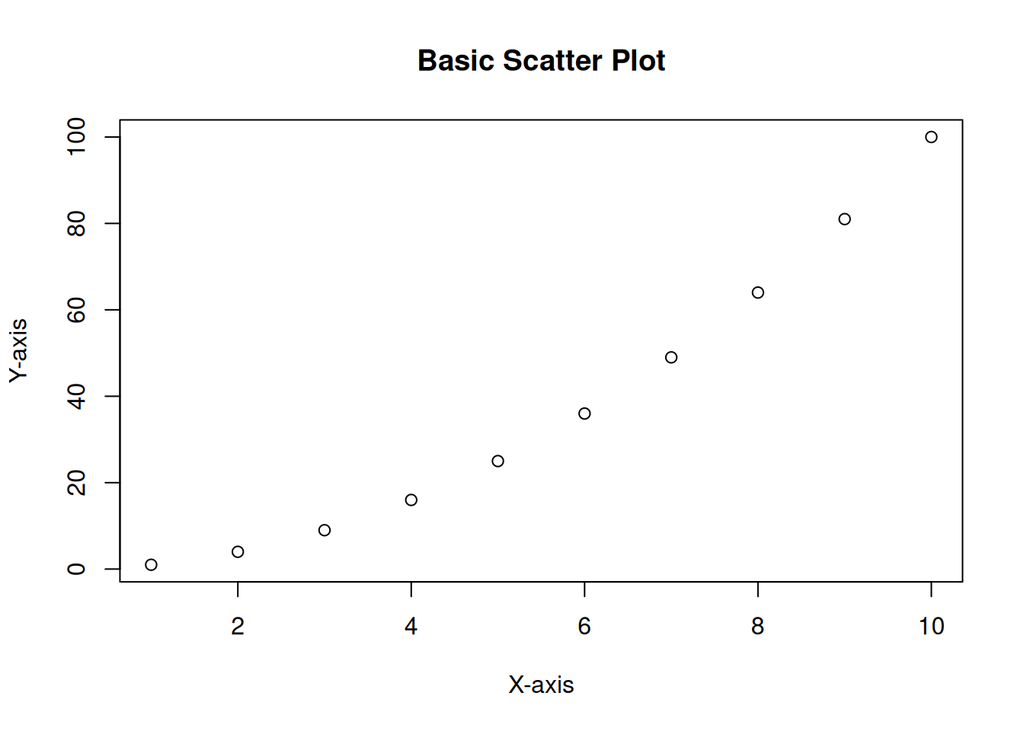

```r
x <- 1:10
y <- x^2
plot(x, y, main = "Basic Scatter Plot", xlab = "X-axis", ylab = "Y-axis")
```

- hist: Creates a histogram, which is useful for visualizing the distribution of a single variable

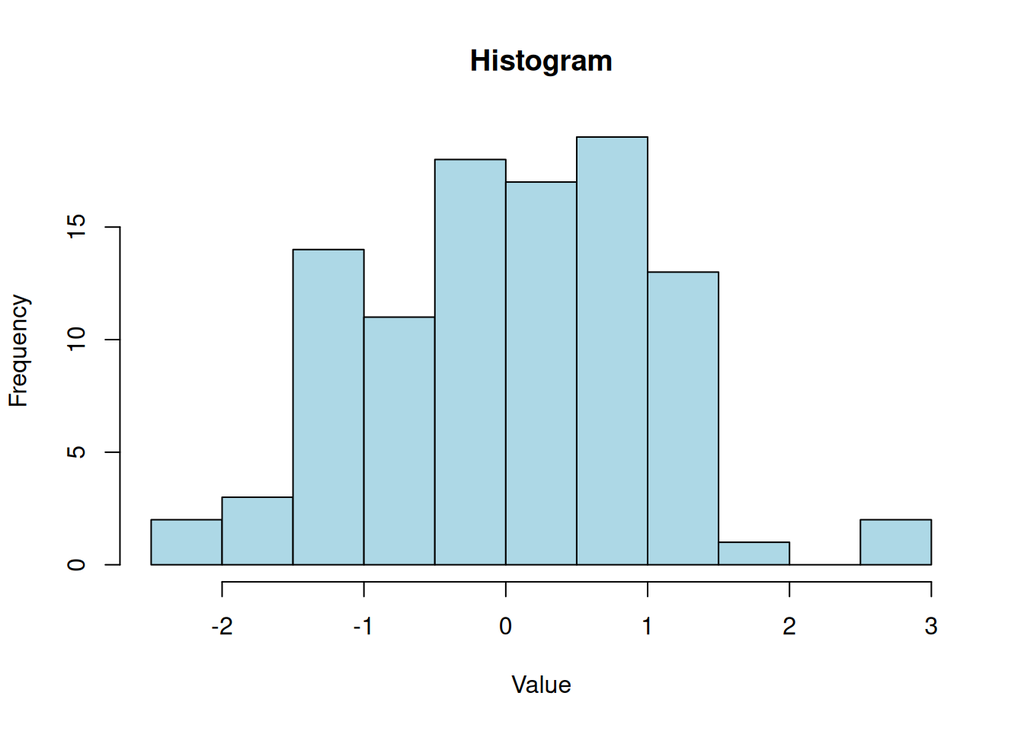

```r
data <- rnorm(100)
hist(data, main = "Histogram", xlab = "Value", col = "lightblue")
```

- barplot: Generates a bar plot, often used to show frequencies or categorical data.

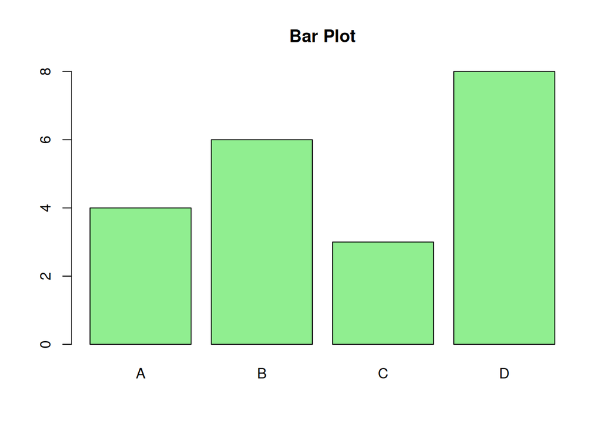

```r
counts <- c(4, 6, 3, 8)
barplot(counts, main = "Bar Plot", names.arg = c("A", "B", "C", "D"), col = "lightgreen")
```

- boxplot: Creates a box plot, which is helpful for visualizing the spread, median, and outliers in data.

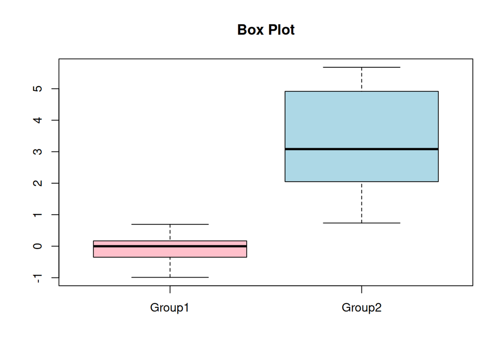

```r
data <- list(Group1 = rnorm(10), Group2 = rnorm(10, mean = 3))
boxplot(data, main = "Box Plot", col = c("pink", "lightblue"))
```

- lineplot: Adds lines to an existing plot, often used to create line graphs.

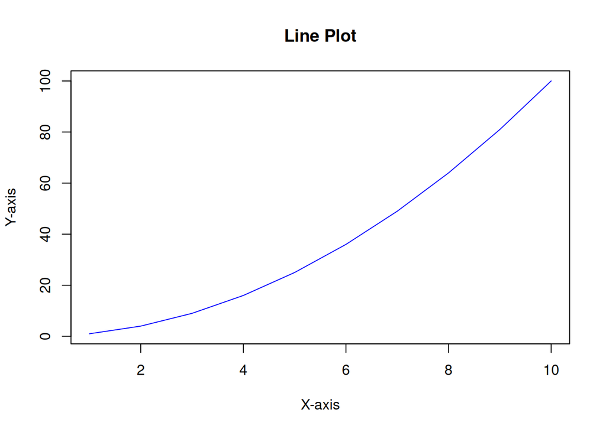

```r
plot(x, y, type = "l", main = "Line Plot", xlab = "X-axis", ylab = "Y-axis", col = "blue")
```

## Functions (Optional)

Sometimes we do not want to repeat code multiple times. The we can create a functions.

In R, a function is a reusable block of code that performs a specific task. Functions help to streamline code, reduce repetition, and make it easier to handle complex operations. R has many built-in functions, and you can also create your own.

- Function Syntax: To call a function, you write its name followed by parentheses. Inside the parentheses, you provide arguments, which are inputs the function uses to perform its task.

```r
my_function <- function_name(argument1 = value1, argument2 = value2) {
  #your code..
}
```

- Arguments: Arguments allow you to customize the behavior of a function. Some arguments are required, while others have default values and can be left out if you don’t need to change them.
- Example: The mean() function calculates the average of a set of numbers. You can pass a vector (list of numbers) to it as the main argument. An additional argument, na.rm, tells the function whether to ignore NA (missing) values.

```r
data <- c(1, 2, 3, NA, 5)
mean(data, na.rm = TRUE)  # na.rm = TRUE removes NAs before calculating the mean
```

```
[1] 2.75
```

To create a function `add` that adds two numeric elements we can write:

```r
add <- function(x, y) {
  result <- x + y
  return(result)
}

add(3, 4)
```

```
[1] 7
```

## If-statements (Optional)

If statements are conditions we can use to manipulate the flow in the code

```r
number <- -5

if (number > 0) {
  print("The number is positive")
} else {
  print("The number is negative")
}
```

```r
score <- 73  # Try different values to test
if (score >= 50) {
  print("Pass")
} else {
  print("Fail")
}
```

## Loops (Optional)

Loops in R are fundamental control structures that allow you to repeat a set of actions multiple times. They are especially useful for tasks that need to be repeated across elements, such as performing calculations on a series of numbers or iterating through rows of a data frame.

For Loop: Used to iterate over a sequence or collection of elements. It’s handy when you know in advance how many times you need to loop.

```r
#Use a for loop to calculate the sum of numbers from 1 to 10.
sum <- 0
for (i in 1:10) {
  sum <- sum + i
}
print(sum)
```

While Loop: Continues looping as long as a specified condition remains TRUE. It’s useful when the number of iterations is not known beforehand.

```r
count <- 1
while (count <= 5) {
  print(count)
  count <- count + 1
}
```

## ggplot2, dplyr, tidyr (Optional)

Here are some examples showing why specific packages from the R ecosystem are useful and how they can simplify data analysis and visualization.

### `ggplot2`: Data Visualization

The `ggplot2` package is part of the tidyverse and is widely used for creating detailed and customizable plots. Unlike base R plotting, `ggplot2` uses a layering approach that makes it easy to build complex plots with aesthetic mappings.

- **Example**: Creating a scatter plot with `ggplot2`

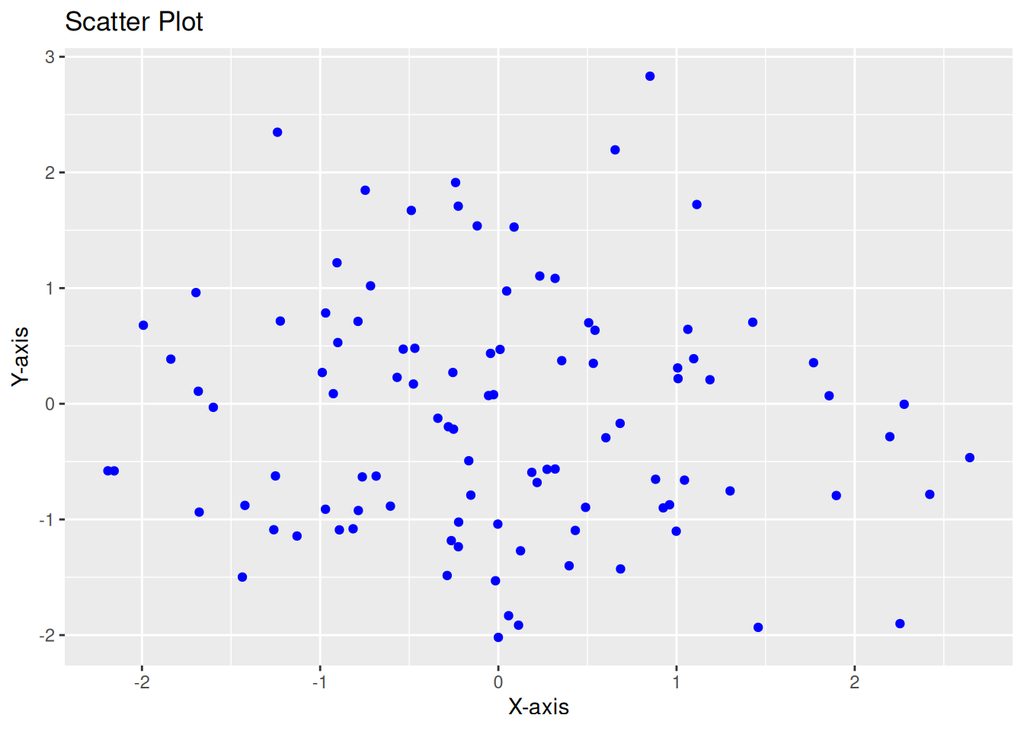

```r
library(ggplot2)
data <- data.frame(x = rnorm(100), y = rnorm(100))

ggplot(data, aes(x = x, y = y)) +
  geom_point(color = "blue") +
  labs(title = "Scatter Plot", x = "X-axis", y = "Y-axis")
```

**Why Use ggplot2**: It allows for easy customization of plots with themes, labels, colors, and more, making it ideal for creating publication-ready graphics.

### `dplyr`: Data Manipulation

The `dplyr` package simplifies data manipulation tasks, providing intuitive functions like `filter()`, `select()`, `mutate()`, and `summarize()`. These functions use “verbs” that make data wrangling operations more readable and expressive.

Remember the pipe `|` from bash? Here we have `%>%` which is essentially the same that we pipe the left input to the next expression (though, the base R has its own pipe `|>`. They work the same. Choose the one you prefer :) ).

- **Example**: Filtering and summarizing data

```r
library(dplyr)
data <- data.frame(name = c("person1", "person2", "person3","person4", "person5", "person6"),
                   age = c(25, 30, 35, 8, 44, 51),
                   height = c(170, 188, 168,120,167,179))

result <- data %>%
  filter(age > 25) |>
  summarize(avg_height = mean(height))
print(result)
```

```
  avg_height
1      175.5
```

**Why Use dplyr**: `dplyr` enables fast and readable manipulation of data, especially with large datasets. It is efficient and often easier to use than base R for complex transformations.

### `tidyr`: Data Tidying

The `tidyr` package is designed to help organize and “tidy” data, making it easier to work with. `Tidyr` includes functions like `gather()`, `spread()`, `pivot_longer()`, and `pivot_wider()` that reshape data to the tidy format, where each variable has its own column and each observation has its own row.

- **Example**: Reshaping data from wide to long format

```r
library(tidyr)
data <- data.frame(id = 1:3, score_math = c(80, 90, 85), score_sci = c(75, 95, 88))

data
```

```
  id score_math score_sci
1  1         80        75
2  2         90        95
3  3         85        88
```

```r
tidy_data <- data %>%
  pivot_longer(cols = starts_with("score"), names_to = "subject", values_to = "score")

tidy_data
```

```
# A tibble: 6 × 3
     id subject    score
  <int> <chr>      <dbl>
1     1 score_math    80
2     1 score_sci     75
3     2 score_math    90
4     2 score_sci     95
5     3 score_math    85
6     3 score_sci     88
```

**Why Use tidyr**: `Tidyr` makes data cleaning and reshaping easier and more systematic, which is essential for preparing data before analysis, especially in projects that require multiple data transformations.

Instead of loading each packages as one we could simply use `library(tidyverse)` (which comes with a lot more packages not covered)